# eprl_uncertainty_future

## Arbitration between incremental and episodic control: Summary and Next Steps

Our initial hypothesis was that when the incremental distribution is more uncertain (the SD is higher), people should be more likely to rely on episodic control, thereby recalling and choosing more high-valued objects when faced with these decisions. This result was not found across four experiments and ~200 participants.

This hypothesis was built around the idea that a less reliable incremental controller should promote episodic control. I think that this might be a different type of uncertainty from the distribution of outcomes itself: it is the noise in the estimate, not the estimate itself. Perhaps it is the case that episodes should be used primarily when the incremental controller fails to estimate the underlying parameters. A noisy estimate is untrustworthy, and thus less reliable.

In our experiments we have been investigating well-learned, and thus less noisy, incremental distributions. This means that the parameters are estimated well in both cases. The only difference, then, is that the spread of outcomes is larger for one than the other. Our results suggest that a controller does not use this type of uncertainty to arbitrate between episodic and incremental decision making for max-valued discrete episodes.

This leaves open two lines of inquiry:

1) Manipulate incremental controller noise with the same basic prediction: that a noisier incremental controller should lead to greater use of episodic control.

2) Investigate whether uncertainty, as measured in our experiments, is used to guide decision heuristics for episodes with more continuous value.

## Does incremental uncertainty determine what episodes to recall and subsequently choose or avoid?

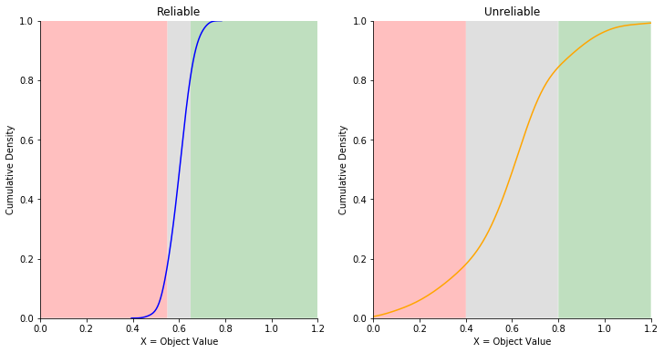

```python
plot_uncertainty_model(relSD=0.05,unrelSD=0.2); plt.show()
```

Once the incremental distributions are learned, a controller might use the (approximate) standard deviation to determine when it is worthwhile to retrieve episodes.

This may occur at tradeoffs governed by the standard deviation. Given imperfect memory as well as people's tendancy to reduce the decision space, this threshold is a useful decision heuristic to maximize outcomes. The upper and lower standard deviation would set two thresholds for retrieval and subsequent choice:

1) Use the upper SD to determine when to retrieve and choose episodes. This indicates the point where it is rare to see incremental outcomes that are this high. Thus, it is useful to switch to episodic control here, because these episodes are worth more than most incremental outcomes.

2) Use the lower SD to determine when to retrieve and avoid episodes. This indicates the point where it is rare to see incremental outcomes that are this low. Thus, it is useful to switch to episodic control here as well, because these episodes are worth less than most incremental outcomes and should be avoided.

Several puzzling aspects of our data can be explained by this idea:

1) This model predicts that people should choose incrementally whenever an episode is not above the upper SD. For one SD, this would be 84% of the time. It is unlikely that people estimate the SD exactly, but the prediction still holds that people should pick the incremental option most of the time.

- For all of our experiments, the incremental option was chosen between 65-70% of the time. Additionally, the "choose incremental" strategy best explained behavior for the largest number of participatns.

2) This model predicts that maximum (and minimum) valued episodes should be chosen at the same rate for both incremental distributions. This means that there should also be no difference between the choice rate for the incremental options themselves (since this is a forced choice task).

- In all experiments (except for participants with high priming accuracy in experiment 4), people choose the incremental options at roughly the same rate.
- In all experiments there is no interaction between value and reliability (again, except for participants with high priming accuracy, who are better at avoiding low-value objects for the distribution with a smaller SD. This may mean that people are more sensitive to the lower SD)

This model actually predicts that for continuous object values the option with a wider spread should be chosen more frequently (which is the opposite of our previous prediction based on what I argue is a different type of uncertainty above).

A version of the task using multiple object values yields the following prediction: A greater number of high value (>SD) and a lower number of low value (<SD) old objects should be chosen for the distribution with a smaller SD.

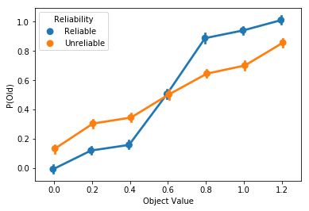

```python
predDf = get_uncertainty_predictions(nSamples = 50)
sns.pointplot(x='Object Value',y='P(Old)',data=predDf,hue='Reliability',
              join=True,dodge=True,hue_order=["Reliable","Unreliable"])
plt.show()
```

## Does incremental noise determine when to utilize episodic control?

It is possible that noise in the incremental controller's estimate is what determines when to utilize episodic control. The logic behind this is that an untrustworthy estimate should yield to highly valuable episodes. This is more in line with Lengyel & Dayan's computational modeling in 2007, where they propose that noise in the model-building system promotes model-free episodic control.

Noise can be created in a number of ways, such as receiving sparse samples about an option or how easily learnable something is. During experiment two we showed participants mixed trial types during training, so we have the opportunity to see if there is more evidence of episodic control early in training for these trial types.

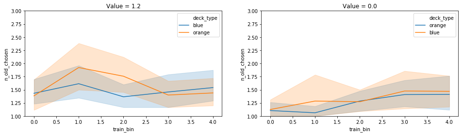

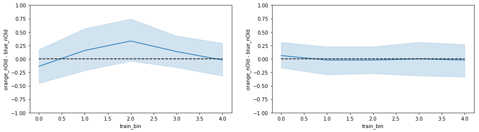

```python
binned_choice_data = plot_exp2training_binned_choice(); plt.show()
binned_withinDifference_data = plot_difference_binned_choice(); plt.show();
```

As in our other experiments, participants tend to choose the incremental option more than the episodic option during these mixed trials and we also show them fewer old objects during training (30%), so there aren't many old objects chosen per training bin. Despite this, we do see a **hint** of the hypothesized relationship, where a greater number of high valued old objects are chosen earlier in training than later in training for the unreliable choices, but not the reliable choices. This is not different at the 95% confidence level, however.

```python
# Importing packages
%matplotlib inline
from __future__ import division
import warnings, os
warnings.filterwarnings('ignore')
import numpy as np
import pandas as pd
import matplotlib.pyplot as plt
import seaborn as sns

def plot_uncertainty_model(relSD=None,unrelSD=None):
    f, axes = plt.subplots(1,2,figsize=(12,6))
    sns.kdeplot(np.random.normal(0.6,relSD,150),cumulative=True,ax=axes[0],color='blue',shade=False)
    sns.kdeplot(np.random.normal(0.6,unrelSD,150),cumulative=True,ax=axes[1],color='orange',shade=False)

    sns.kdeplot(np.random.uniform(0.6+relSD,1.2,1000),ax=axes[0],color='green',shade=True,cut=0)
    sns.kdeplot(np.random.uniform(0.6+unrelSD,1.2,1000),ax=axes[1],color='green',shade=True,cut=0)
    sns.kdeplot(np.random.uniform(0.6-relSD,0.6+relSD,1000),ax=axes[0],color='grey',shade=True,cut=0)
    sns.kdeplot(np.random.uniform(0.6-unrelSD,0.6+unrelSD,1000),ax=axes[1],color='grey',shade=True,cut=0)
    sns.kdeplot(np.random.uniform(0,0.6-relSD,1000),ax=axes[0],color='red',shade=True,cut=0)
    sns.kdeplot(np.random.uniform(0,0.6-unrelSD,1000),ax=axes[1],color='red',shade=True,cut=0)

    titles = ['Reliable','Unreliable']
    for i_ax, ax in enumerate(axes):
        ax.set_ylim(0,1); ax.set_xlim(0,1.2);
        ax.set_ylabel("Cumulative Density"); ax.set_xlabel("X = Object Value");
        ax.set_title(titles[i_ax])

    sns.despine()

def get_uncertainty_predictions(nSamples=50):
    distTypes = ['Unreliable','Reliable']
    vals = [0,0.2,0.4,0.6,0.8,1,1.2]
    unrel_ys = [0.15, 0.3, 0.35, 0.5, 0.65, 0.7, 0.85]
    rel_ys = [0, 0.1, 0.15, 0.5, 0.9, 0.95, 1.0]
    xVals, relLabels, yVals = [], [], []
    for reliability in distTypes:
        if reliability == 'Unreliable':
            y_vals = unrel_ys
        else:
            y_vals = rel_ys
        for i_val, val in enumerate(vals):
            xVals.append([val] * nSamples)
            relLabels.append([reliability] * nSamples)
            yVals.append(np.random.normal(y_vals[i_val],0.1,nSamples))

    xVals = [i for j in xVals for i in j]
    relLabels = [i for j in relLabels for i in j]
    yVals = [i for j in yVals for i in j]
    predDf = pd.DataFrame.from_dict({'Object Value':xVals,'P(Old)':yVals,'Reliability':relLabels})
    return predDf

def loadData(dType=None,dataDir="/Users/jonathan/shohamylab/jspych-exps/data/exp2",fileType="stateData"):
    data, exclude_pids = [], []
    dataFiles = [d for d in os.listdir(dataDir) if dType in d]
    for f in dataFiles:
        subData = pd.read_csv(os.path.join(dataDir,f))
        if dType == "interaction":
            if len(subData[subData.event == 'blur']) >= exclude_blur:
                exclude_pids.append(f.split('_')[0])
            subData['subjectID'] = [f.split('_')[0]] * len(subData)
        elif dType == "experiment":
            bonus = float(f.split('_')[2].replace('bonus',''))
            subData['bonus'] = [bonus] * len(subData)
        data.append(subData)
    data = pd.concat(data,ignore_index=True)
    return data, exclude_pids

def plot_exp2training_binned_choice():
    data = loadData(dType="experiment")[0]
    train_data = data[data.test_part == "train"]
    train_data = train_data[train_data.choice != 'no_response']

    mixed_data = train_data[train_data.train_trial_type == "both"]
    mixed_data.loc[mixed_data['choice'].str.contains('object'), 'choice'] = 'object'

    def bin_train_data(row,n_bins=5):
        nTrainTrials = 300
        nPerBin = int(nTrainTrials/n_bins)
        binEdges = list(range(nPerBin+1,nTrainTrials+nPerBin+1,nPerBin))
        if row.trial_number <= nTrainTrials:
            currBin = [n for n,i in enumerate(binEdges) if i>row.trial_number ][0]
            return currBin
        else: return np.nan

    mixed_data['train_bin'] = mixed_data.apply(lambda row: bin_train_data(row),axis=1)

    mixed_data['earned'] = mixed_data['earned'].astype(float)
    binned_choice_data = mixed_data[(mixed_data.choice == "object") &
                                   (mixed_data.old_trial == True)].groupby(['subjectID',
                                                                           'train_bin',
                                                                           'deck_type',
                                                                           'earned']) \
                                                                  .size().reset_index(name="n_old_chosen")

    f, axes = plt.subplots(1,2,figsize=(16,4))
    sns.lineplot(x='train_bin',y='n_old_chosen',hue='deck_type',
                  data=binned_choice_data[binned_choice_data['earned'] == 1.2],ax=axes[0])
    sns.lineplot(x='train_bin',y='n_old_chosen',hue='deck_type',
                  data=binned_choice_data[binned_choice_data['earned'] == 0],ax=axes[1])
    for ax in axes:
        ax.set_ylim(1,3)
    axes[0].set_title('Value = 1.2')
    axes[1].set_title('Value = 0.0')

    return binned_choice_data

def plot_difference_binned_choice():
    diffDf = {k:[] for k in ['subjectID','train_bin','orange_nOld - blue_nOld','earned']}
    for amt in [1.2,0]:
        high_binned_data = binned_choice_data[binned_choice_data.earned == amt]
        pids = high_binned_data.subjectID.unique()
        bins = high_binned_data.train_bin.unique()
        out = {k:[] for k in ['subjectID','train_bin','deck_type','earned','n_old_chosen']}

        for pid in pids:
            pid_data = high_binned_data[high_binned_data.subjectID == pid]
            for b in bins:
                to_add, to_repeat = [], []
                bin_data = pid_data[pid_data.train_bin == b]
                if not bin_data.empty:
                    if 'orange' not in list(bin_data.deck_type):
                        to_add.append('orange')
                    else:
                        to_repeat.append('orange')

                    if 'blue' not in list(bin_data.deck_type):
                        to_add.append('blue')
                    else:
                        to_repeat.append('blue')

                    for d in to_repeat:
                        n_old_chosen = bin_data[bin_data.deck_type == d].n_old_chosen.iloc[0]
                        out['subjectID'].append(pid)
                        out['train_bin'].append(b)
                        out['deck_type'].append(d)
                        out['earned'].append(amt)
                        out['n_old_chosen'].append(n_old_chosen)
                else:
                    to_add.append('blue')
                    to_add.append('orange')
                for d in to_add:
                    out['subjectID'].append(pid)
                    out['train_bin'].append(b)
                    out['deck_type'].append(d)
                    out['earned'].append(amt)
                    out['n_old_chosen'].append(0)
        outDf = pd.DataFrame.from_dict(out)
        diffs = np.array(outDf[outDf.deck_type == 'orange'].n_old_chosen) \
                - np.array(outDf[outDf.deck_type == 'blue'].n_old_chosen)
        for i_diff, diff in enumerate(diffs):
            diffDf['orange_nOld - blue_nOld'].append(diff)
            diffDf['subjectID'].append(outDf[outDf.deck_type == 'blue'].subjectID.iloc[i_diff])
            diffDf['train_bin'].append(outDf[outDf.deck_type == 'blue'].train_bin.iloc[i_diff])
            diffDf['earned'].append(outDf[outDf.deck_type == 'blue'].earned.iloc[i_diff])
    diffDf = pd.DataFrame.from_dict(diffDf)
    f, axes = plt.subplots(1,2,figsize=(16,4))
    sns.lineplot(x='train_bin',y='orange_nOld - blue_nOld',data=diffDf[diffDf.earned == 1.2],ax=axes[0])
    sns.lineplot(x='train_bin',y='orange_nOld - blue_nOld',data=diffDf[diffDf.earned == 0],ax=axes[1])
    for ax in axes:
        ax.set_ylim(-1,1)
        ax.plot((0,4),(0,0),'k--')
    return diffDf
```